# PTT-movie

CARTUS YOU

2018年7月22日

## Purpose

```r
setwd('D:/2018.07 R_DataAnalysis/2018SUMMER_R/data')

library(bitops)
library(httr)
library(RCurl)
library(XML)
library(tm)
library(NLP)
library(tmcn)
library(jiebaRD)
library(jiebaR)
```

> Organizing Data
- Create Corpus with the data sorting by posting time.
- Delete the words that could influnce the result.

```r
d.corpus <- Corpus( DirSource("./0721") )
toSpace <- content_transformer(function(x, pattern) {
  return (gsub(pattern, " ", x))
}
)
d.corpus <- tm_map(d.corpus, toSpace, "場")
d.corpus <- tm_map(d.corpus, toSpace, "場想")
d.corpus <- tm_map(d.corpus, removePunctuation)
d.corpus <- tm_map(d.corpus, removeNumbers)
d.corpus <- tm_map(d.corpus, function(word) {
  gsub("[A-Za-z0-9]", "", word)
})
```

> Create TermDocumentMatrix
- Split the contents into words with jieba package.
- Count the time each words appears in the content of each hours.
- Create the TermDocumentMatrix with columns of each hours.

```r
mixseg = worker()
jieba_tokenizer = function(d)
{
  unlist( segment(d[[1]], mixseg) )
}
seg = lapply(d.corpus, jieba_tokenizer)

count_token = function(d)
{
  as.data.frame(table(d))
}
tokens = lapply(seg, count_token)

n = length(seg)
TDM = tokens[[1]]
colNames <- names(seg)
colNames <- gsub(".txt", "", colNames)
for( id in c(2:n) )
{
  TDM = merge(TDM, tokens[[id]], by="d", all = TRUE)
  names(TDM) = c('d', colNames[1:id])
}
TDM[is.na(TDM)] <- 0
library(knitr)
kable(head(TDM))
```

| d | 00 | 01 | 02 | 03 | 04 | 05 | 06 | 07 | 08 | 09 | 10 | 11 | 12 | 13 | 14 | 15 | 16 | 17 | 18 | 19 | 20 | 21 | 22 | 23 |
| --- | --- | --- | --- | --- | --- | --- | --- | --- | --- | --- | --- | --- | --- | --- | --- | --- | --- | --- | --- | --- | --- | --- | --- | --- |
|  | 29 | 46 | 16 | 1 | 24 | 11 | 1 | 2 | 23 | 6 | 6 | 13 | 110 | 79 | 15 | 39 | 38 | 11 | 20 | 31 | 151 | 40 | 41 | 10 |
| ︵ | 1 | 0 | 0 | 0 | 0 | 0 | 0 | 0 | 0 | 0 | 0 | 0 | 0 | 0 | 0 | 0 | 0 | 0 | 0 | 0 | 0 | 0 | 0 | 0 |
| ︳ | 1 | 0 | 0 | 0 | 0 | 0 | 0 | 0 | 0 | 0 | 0 | 0 | 0 | 0 | 0 | 0 | 0 | 0 | 0 | 0 | 0 | 0 | 0 | 0 |
| ㄇ | 3 | 1 | 3 | 0 | 0 | 0 | 0 | 0 | 0 | 0 | 2 | 4 | 1 | 0 | 0 | 9 | 0 | 7 | 3 | 1 | 0 | 1 | 0 | 0 |
| ㄉ | 2 | 0 | 0 | 0 | 0 | 0 | 0 | 1 | 0 | 0 | 0 | 1 | 0 | 0 | 0 | 0 | 0 | 0 | 1 | 1 | 0 | 1 | 1 | 1 |
| ㄎ | 2 | 0 | 1 | 1 | 0 | 3 | 1 | 0 | 5 | 0 | 2 | 8 | 4 | 1 | 8 | 2 | 1 | 0 | 6 | 0 | 1 | 79 | 1 | 7 |

> Tranform TDM into TF-IDF
- Calculate the term frequency.
- Calculate inverse document frequency.
- Multiply TF and IDF to create TF-IDF dataframe.

```r
tf <- apply(as.matrix(TDM[,2:(n+1)]), 2, sum)

library(Matrix)
idfCal <- function(word_doc)
{
  log2( n / nnzero(word_doc) )
}
idf <- apply(as.matrix(TDM[,2:(n+1)]), 1, idfCal)

doc.tfidf <- TDM
# for(x in 1:nrow(TDM))
# {
#   for(y in 2:ncol(TDM))
#   {
#     doc.tfidf[x,y] <- (doc.tfidf[x,y] / tf[y]) * idf[x]
#   }
# }

tempY = matrix(rep(c(as.matrix(tf)), each = length(idf)), nrow = length(idf))
tempX = matrix(rep(c(as.matrix(idf)), each = length(tf)), ncol = length(tf), byrow = TRUE)
doc.tfidf[,2:(n+1)] <- (doc.tfidf[,2:(n+1)] / tempY) * tempX

stopLine = rowSums(doc.tfidf[,2:(n+1)])
delID = which(stopLine == 0)

kable(head(doc.tfidf[delID,1]))
```

| x |
| --- |
| 一 |
| 一下 |
| 一次 |
| 一些 |
| 一定 |

> Find Key Words
- Reverse the TF-IDF dataframe.
- Sorting the TF-IDF to get the key words in each hour.

```r
TDM = TDM[-delID,]
doc.tfidf = doc.tfidf[-delID,]

TopWords = data.frame()
for( id in c(1:n) )
{
  dayMax = order(doc.tfidf[,id+1], decreasing = TRUE)
  showResult = t(as.data.frame(doc.tfidf[dayMax[1:5],1]))
  TopWords = rbind(TopWords, showResult)
}
rownames(TopWords) = colnames(doc.tfidf)[2:(n+1)]
TopWords = droplevels(TopWords)
kable(TopWords)
```

|  | V1 | V2 | V3 | V4 | V5 |
| --- | --- | --- | --- | --- | --- |
| 00 | 艾莎 | 安娜 | 漢斯 | 鯊魚 | 王傳君 |
| 01 | 拜金女 | 潔西 | 史丹 | 小婦人 | 查克 |
| 02 | 貝克 | 亡靈 | 柴房 | 鍾 | 世紀末 |
| 03 | 高調 | 沉沒 | 戀童 | 律法 | 嘔 |
| 04 | 台版 | 福爾摩沙 | 港版 | 凡赫辛 | 日版 |
| 05 | 大舌頭 | 口音 | 威猛 | 女童 | 周浩旻 |
| 06 | 朱諾 | 張作驥 | 飆風 | 莎拉 | 獅子王 |
| 07 | 荷語 | 原唱 | 法語區 | 比利時 | 雙語 |
| 08 | 南部 | 書店 | 佛蘿倫絲 | 古惑仔 | 街角 |
| 09 | 吼吼 | 王童 | 羅利 | 飲茶 | 毒戰 |
| 10 | 辣媽 | 藍波 | 曾莞婷 | 遠藤 | 硬塞 |
| 11 | 水底 | 一級 | 光劍 | 情深 | 玩家 |
| 12 | 宗秀 | 小婦人 | 阿瑪迪斯 | 司馬懿 | 斧頭 |
| 13 | 鬥技 | 聖杯 | 佛蘿倫絲 | 返校 | 乒乓 |
| 14 | 候補 | 石內卜 | 休斯頓 | 羅賓 | 威廉斯 |
| 15 | 辛巴達 | 噤界 | 大獲全勝 | 西藏 | 封神 |
| 16 | 溥儀 | 筷子 | 花與蛇 | 宗秀 | 福音戰士 |
| 17 | 中午 | 墨菲 | 原班人馬 | 家教 | 攔住 |
| 18 | 中午 | 阿湯哥 | 終 | 想看 | 美崙 |
| 19 | 德華 | 青雲 | 詠琪 | 胡牌 | 發脾氣 |
| 20 | 十三日 | 追逐 | 七月 | 命 | 家明 |
| 21 | 腸腸 | 滑雪 | 鍾 | 海美 | 宅宅 |
| 22 | 副標題 | 露德 | 救援 | 美紀 | 輪椅 |
| 23 | 聖司 | 閱歷 | 用筆 | 電看 | 海潮 |

> Visualization
- Create Topwords to get the key words with higest frequency.

```r
TDM$d = as.character(TDM$d)
AllTop = as.data.frame( table(as.matrix(TopWords)) )
AllTop = AllTop[order(AllTop$Freq, decreasing = TRUE),]

kable(head(AllTop))
```

|  | Var1 | Freq |
| --- | --- | --- |
| 10 | 小婦人 | 2 |
| 11 | 中午 | 2 |
| 32 | 佛蘿倫絲 | 2 |
| 39 | 宗秀 | 2 |
| 106 | 鍾 | 2 |
| 1 | 一級 | 1 |

- See how often the key words appeared in each hour.

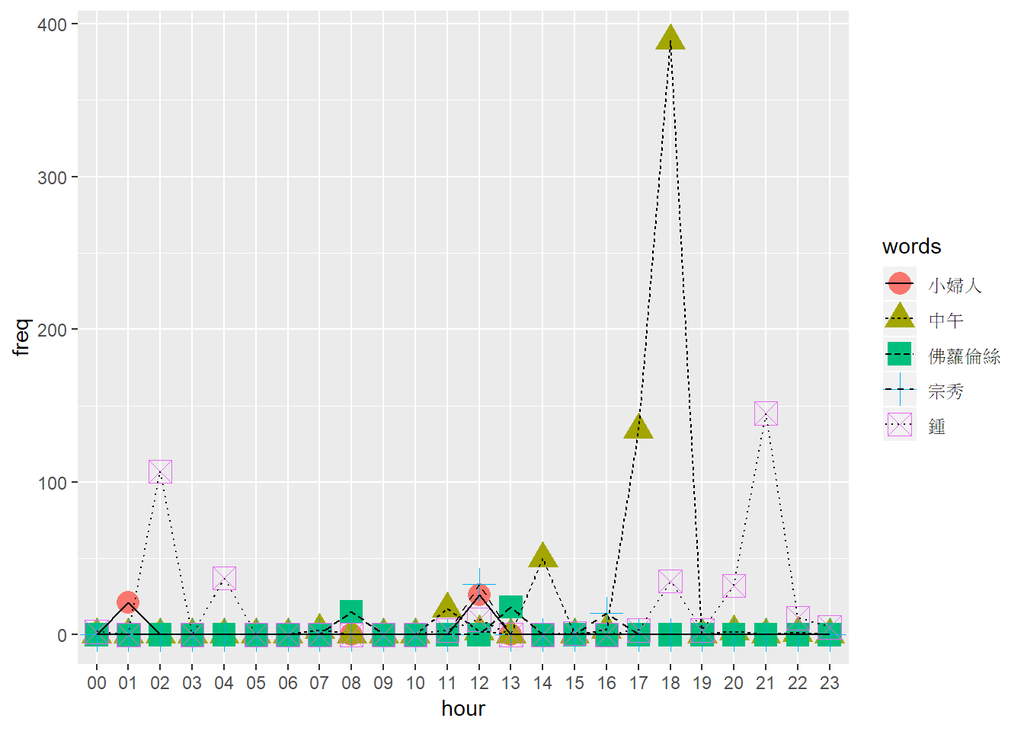

```r
TopNo = 5
tempGraph = data.frame()
for( t in c(1:TopNo) )
{
  word = matrix( rep(c(as.matrix(AllTop$Var1[t])), each = n), nrow = n )
  temp = cbind( colnames(doc.tfidf)[2:(n+1)], t(TDM[which(TDM$d == AllTop$Var1[t]), 2:(n+1)]), word )
  colnames(temp) = c("hour", "freq", "words")
  tempGraph = rbind(tempGraph, temp)
  names(tempGraph) = c("hour", "freq", "words")
}

library(ggplot2)
library(varhandle)
tempGraph$freq = unfactor(tempGraph$freq)
ggplot(tempGraph, aes(hour, freq)) +
  geom_point(aes(color = words, shape = words), size = 5) +
  geom_line(aes(group = words, linetype = words))
```

- See the amount of posts in each hour.

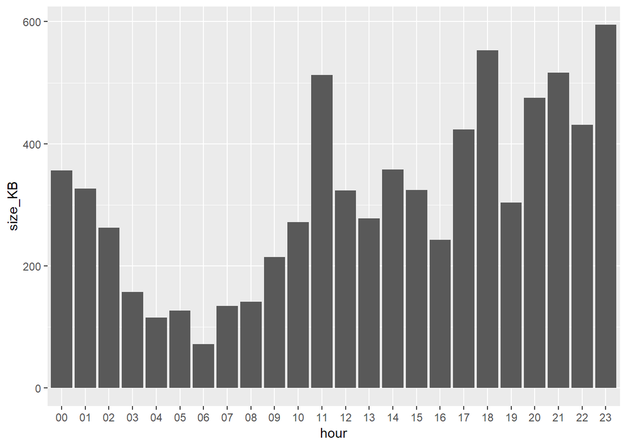

```r
filenames = as.array(paste0("./0721/",colnames(doc.tfidf)[2:(n+1)],".txt"))
sizeResult = apply(filenames, 1, file.size) / 1024
showSize = data.frame(colnames(doc.tfidf)[2:(n+1)], sizeResult)
names(showSize) = c("hour", "size_KB")

ggplot(showSize, aes(x = hour, y = size_KB)) + geom_bar(stat="identity")
```